# LSIRM 2018 - Introduction to R - Tutorial 2

Simon Kiss

2018-06-19

```r
knitr::opts_chunk$set(echo = TRUE, warning=F, message=F,  results='hide', fig.width=4, fig.height=3, fig.align='center')
```

# Working With Data

## Reading Data In

R has a number of functions meant to read data in from a variety of formats. The core functions are `read.table()` for plain text files, `read.csv()` for .csv files. More elaborate files (e.g. SPSS or Stata) require more advanced functions. The three main libraries that offer functions that read SPSS or Stata files are the `foreign`, `haven`, and `rio` libraries. `Foreign` is the oldest, `haven` and `rio` are newer. `Haven` was desiged by Hadley Wickham, architect of the whole suite of the `tidyverse`.

Ulimately, I think `haven` works the best, but it does involve the steepest learning curve.

My recommendation is to use the `haven` library to read SPSS and Stata files in.

Because it is part of the core set of `tidyverse` libraries, we load it with the `tidyverse` package.

However, one of the key innovations of `haven` is a new class of variable, the `labelled` class. To really deal with `labelled` variables, it is best to load the `labelled` library as well.

## Reading in our Data set

```r
#read-in
#load haven
library(haven)
#load labelled
library(labelled)

ces<-read_sav('https://github.com/sjkiss/LSIRM_2018/raw/master/data/ces15_data.sav')
```

# Summarizing Data Frames

After reading data in, it is usually a good idea to inspect the data to get a feel for what you have read in.

There are a few commands that can be useful to inspect data frames.

```r
###examine-data
#Different ways of summarizing the data set
#Check the first few rows
head(ces)
#The last few rows
tail(ces)
#Check the structure of the object
str(ces)
#Summarize the data set
summary(ces)
#See the variables names
names(ces)
```

#### Assignment 1

> 1. Are there any values that look suspicious?

# Looking at value labels.

When you import SPSS or STATA data sets via the data with the `haven` package, R imports valuable metadata associated with each variable, including the variable label and the value labels. The variable and value labels are can be accessed with the following commands: `var_label` for variable labels and `val_labels` for value labels.

```r
#get-labels
var_label(ces)
val_labels(ces)
```

#### Assignment 2

> 1. Save the variable labels and value labels as two separate objects (`vars` and `vals`) so we can look through them later.

```r
vars<-var_label(ces)
vals<-val_labels(ces)
```

#### Assignment 3

> 1. Look at the value labels and take note of what are missing values that need to be Recoded.

```r
vals
```

```
## $p_incineq
##                   Yes                    No            Don't Know
##                     1                     2                     3
##      Refuse to Answer    Don't Know/Refused Seen But Not Answered
##                     4                   998                  1000
##
## $income_full
##     Less than $30,000    $30,000 to $60,000    $60,000 to $90,000
##                     1                     2                     3
##   $90,000 to $110,000    More than $110,000            Don't Know
##                     4                     5                     6
##      Refuse to Answer    Don't Know/Refused Seen But Not Answered
##                     7                   998                  1000
##
## $p_selfplace
## NULL
##
## $education
##                                                     No Schooling
##                                                                1
##                                           Some Elementary School
##                                                                2
##                                      Completed Elementary School
##                                                                3
##                                     Some Secondary / High School
##                                                                4
##                                Completed Secondary / High School
##                                                                5
##      Some Technical, Community College, CEGEP, College Classique
##                                                                6
## Completed Technical, Community College, CEGEP, College Classique
##                                                                7
##                                                  Some University
##                                                                8
##                                                Bachelor's Degree
##                                                                9
##                                                  Master's Degree
##                                                               10
##                                 Professional Degree or Doctorate
##                                                               11
```

[output cut: 33 more lines]

```
##                  1000
##
## $p_gap
##             Much More         Somewhat More About the Same as Now
##                     1                     2                     3
##         Somewhat Less             Much Less            Don't Know
##                     4                     5                     6
##      Refuse to Answer    Don't Know/Refused Seen But Not Answered
##                     7                   998                  1000
##
## $sex_r
##                  Male                Female      Refuse to Answer
##                     1                     2                     3
##    Don't Know/Refused Seen But Not Answered
##                   998                  1000
```

# Recoding variables

It looks like for every variable, except for `p_selfplace`, we can recode values 998 to 1000 to be missing. But in addition, some variables respondents also picked `don't know` or `refuse`. Some might try to make use of those data, but we’ll just dump them for the moment.

The easiest function to recode variables is the `Recode` command in the `car` library.

Please note: there is a conflict between two recode commands; namely, there exists a `recode` in the `car` library (specified as `car::recode`) and in the `dplyr` library (part of the `tidyverse`, `dplyr::recode`). If one package is loaded *after* the other, then the first package’s command is masked. To rectify this conflict, the author of the `car` package added a version of the same command that is capitalized, i.e. `Recode().` Fundamentally, the best way to avoid this is to use capital-R `Recode` from the `car` library. That will *always* and *only* call the `car::recode` command.

```r
Recode(x, "old value=new value")
```

```r
#load the car library
library(car)
#Recode 1
test<-Recode(ces$p_incineq,"3:1000=NA")
#Recode 2
test2<-Recode(ces$p_incineq, "3=NA; 4=NA; 998=NA; 1000=NA")
#Summary test
summary(test)
```

```
##    Min. 1st Qu.  Median    Mean 3rd Qu.    Max.    NA's
##   1.000   1.000   1.000   1.215   1.000   2.000    4009
```

```r
#class test
class(test)
```

```
## [1] "labelled"
```

```r
#summary test 2
summary(test2)
```

```
##    Min. 1st Qu.  Median    Mean 3rd Qu.    Max.    NA's
##   1.000   1.000   1.000   1.215   1.000   2.000    4009
```

There are a few things to notice about the `Recode()` command. Overall, the recodes are put in **double-quotes** . Each individual recode is separated with a semi-colon. And normally, if you are recoding character strings, you use single-quotes. But, because NA is a reserved character string denoting missing data, it is unquoted.

Notice now that, after the recode, the maximum value is 2. We’ve set missing values to be `NA` and they are not counted when we use `summary()`

We also just dumped that recode result in a quick temporary variable called `test`. What we really want is to save it in a new variable caled `inequal`. When you execute this command, watch what happens to the environment in the top right corner. We can also recode numbers to factors. In this case, it might make more sense to turn `inequal` into a factor.

```r
ces$inequal<-Recode(ces$p_incineq, "1='Yes' ; 2='No'; 3:1000=NA", levels=c('No', 'Yes'), as.factor=T)
vals
```

There are a few things to note here. First, note that, inside the recodes, numbers are not quoted, but character strings are, with single-quotes. Second, there is an additional argument, `levels` that takes a character vector the order of which is important. The first level of the factor is the reference categor. Lastly, there is the argument `as.factor` which is logical (i.e. either `TRUE` or `FALSE`). If TRUE, the new variable is stored a s a factor, if FALSE it is stored as just a character string.

Often, when you do Recodes, it is also useful to change the names of the variables, to something more user friendly. This has the added advantage of also keeping the original variables intact, just incase you make a mistake.

#### Assignment 4

> 1. Recode `income_full`, `p_selfplace` , `education` and `sex_r` such that missing values are converted to NA. Save `income_full` as `income` and `p_selfplace` as `ideology`. You will have to go back and forth to `vals` to remind yourself of what the missing values are. Recode education into a new variable, `degree` which has the levels `no degree` and `degree`. Recode `sex_r` to `gender` using `M` and `F`. Set `M` to be the reference category. Check `vals` to get the range of values right.

```r
#education
vals$education
#education missing values
ces$education<-Recode(ces$education, "12:1000=NA")
#degree
#check vals
vals
#Recode eduation to degree
ces$degree<-Recode(ces$education, "1:7='No degree' ; 8:11='Degree'", levels=c('No degree', 'Degree'), as.factor=T)

#Income missing values
ces$income<-Recode(ces$income_full, "6:1000=NA")

#Recode p_selfplace
ces$ideology<-Recode(ces$p_selfplace, "1000=NA")

#recode gender
ces$gender<-Recode(ces$sex_r, "1='M' ; 2='F'", levels=c('M', 'F'), as.factor=T)
```

Note: There are ways to automate this and we’ll deal with those tomorrow.

```r
#check summary
summary(ces)
#check structure
str(ces)
```

# Describing results

Produce a table of descriptive results.

```r
library(psych)
desc<-describe(ces)
```

# Plotting

To do our plotting, we will make use of the `ggplot2` library, party of the core suite of `tidyverse` packages.

```r
#load full tidyverse
library(tidyverse)
```

This is where the fun begins.

Base R’s graphics are built around the `plot()` command. The tidyverse’s `ggplot2` plotting function is much more systematic and built on consistent principles. It’s basically better.

The `ggplot()` command is the basic command which contains the basic parameters of a graph and then specifics are added to it. Below, we specify the underlying data – `ces` – and one of the two most important aesthetics of a graph, the x variable. Note: in ggplot2 ``aesthetics’’ has a very particular meaning. Namely, it maps particular visual features of a plot (i.e. color, shape of points, type of line, the fill of bars) to the values of variables (see the figure below).

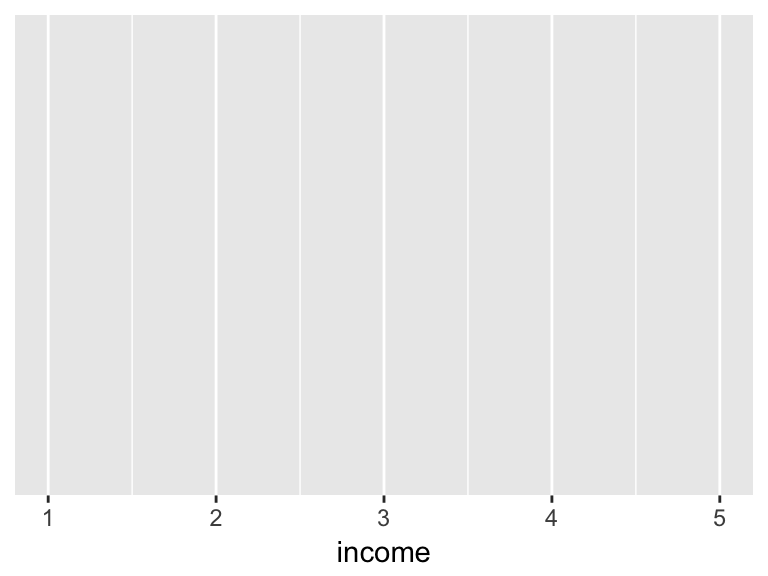

No plot!

```r
ggplot(ces, aes(x=income))
```

But nothing appears. This is because the second core aspect of the plot is the `geom` These are the graphical types of representing the relationship between x and y (see the next figure).

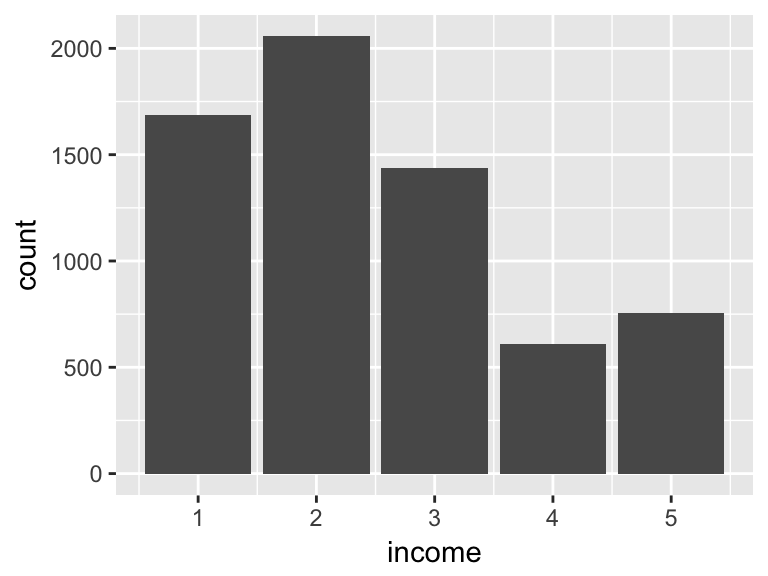

```r
#Add barplot

  ggplot(ces, aes(x=income))+
  geom_bar()
```

## Types of geoms()

There are *a ton* of geoms in the `ggplot2` library. See the [cheatsheet](https://www.rstudio.com/wp-content/uploads/2015/03/ggplot2-cheatsheet.pdf) for details.

#### Assignment 6

> 1. Produce a density plot of ideology. Save it as `plot1`. print plot1

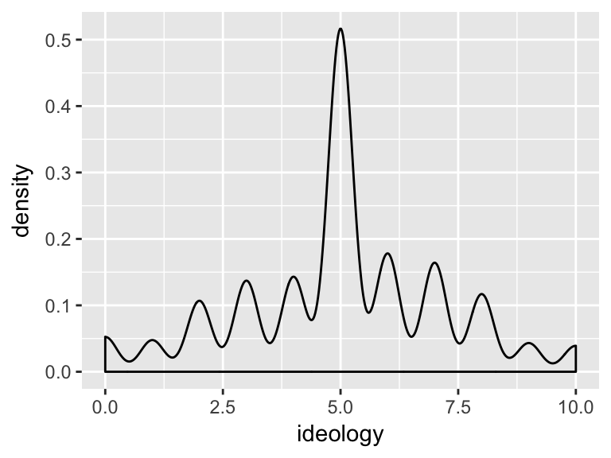

```r
#save plot1
plot1<- ggplot(ces, aes(x=ideology))+geom_density()

#print
plot1
```

You can modify the colors and visual aspects of the plot in the `geom()` section. When you just want to force the plot to show colors and not be linked or mapped to another variable, you just set the aesthetic (e.g. `color`, `linetype`, `size` or `width` to be a particular value). Handily, to update a plot, you can call the plot and just add a replacement `geom()` to it.

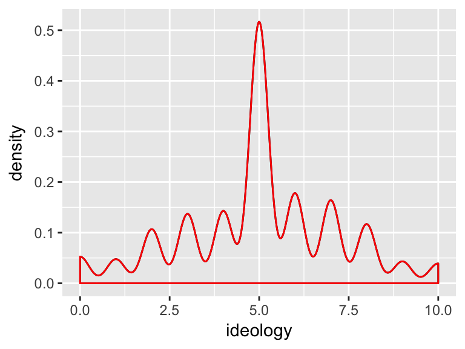

```r
plot1+geom_density(col='red')
```

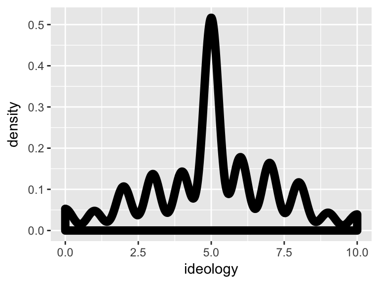

```r
plot1+geom_density(size=3)
```

Note: not all `geoms()` accept all aesthetics. This:

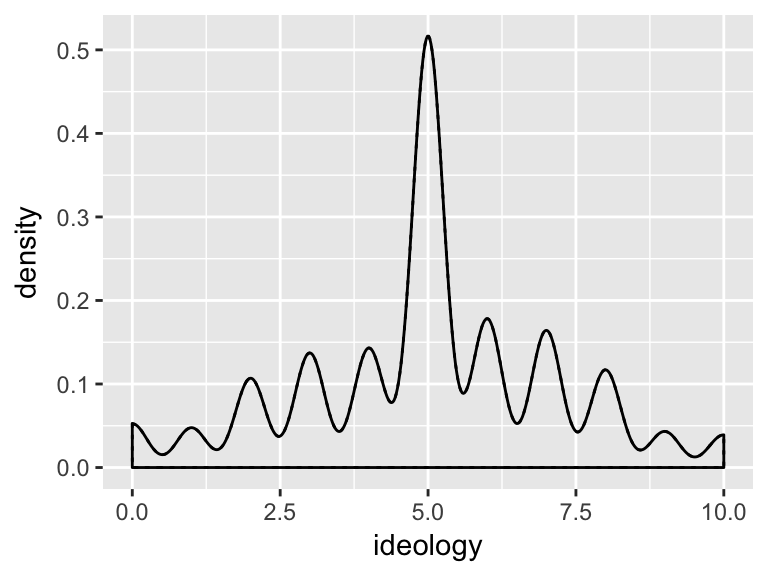

Changing linetype on a densit plot does not do anything.

```r
plot1+geom_density(linetype=3)
```

does not change anything, because changing linetypes on density plots is not meanningful.

Making bivariate plots is just a matter of adding in a y-variable for the y-axis.

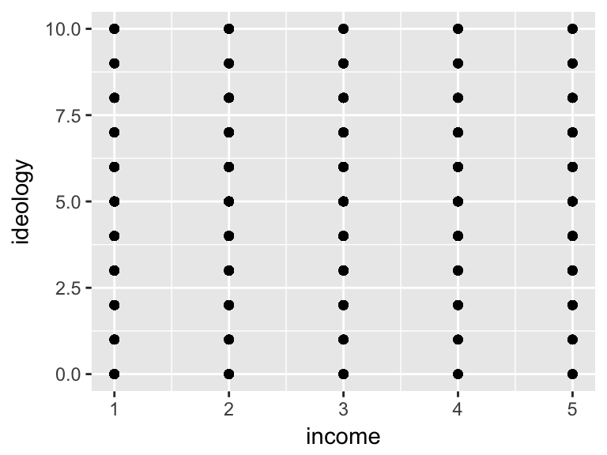

A basic scatterplot

```r
  ggplot(ces, aes(x=income, y=ideology))+
  geom_point()
```

#### Assignment 7

> 1. Make a scatterplot with education on the x-axis and ideology on the y-axis
> 2. Make a boxplot with education on the x-axis and ideology on the y-axis

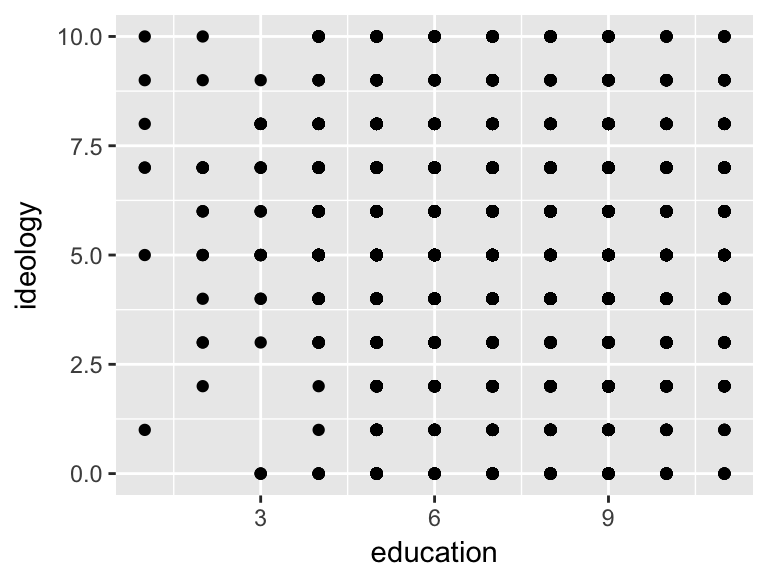

```r
#Scatterplot
plot2<-ggplot(ces, aes(x=education, y=ideology))+geom_point()
plot2
```

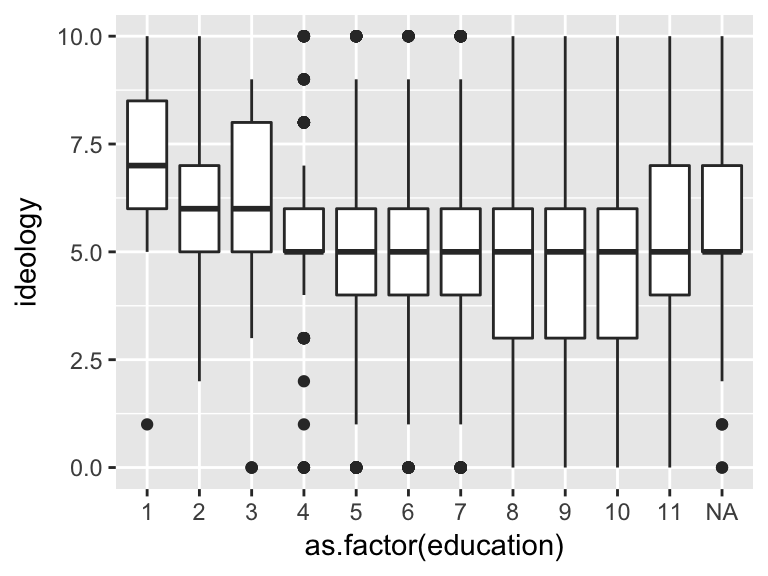

```r
#Boxplot
plot3<-ggplot(ces, aes(x=as.factor(education) ,y=ideology))+geom_boxplot()
plot3
```

Very quickly, we can also add in third grouping variables. Like education and / or gender.

We can do gender as follows.  
The key is to use the `aes()` argument in the `geom()` to map a specific visuable attribute of the plot to values of the grouping variable.

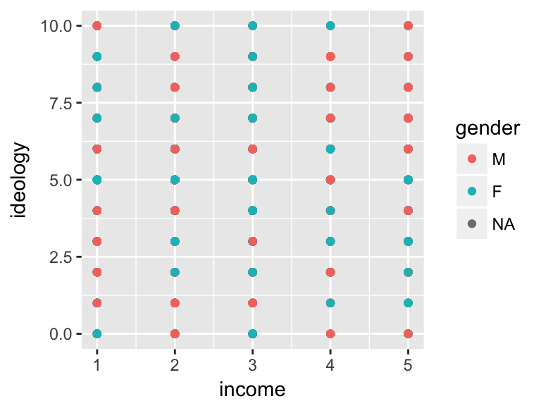

```r
#Make plot 4, save as plot4
plot4<-ggplot(ces, aes(x=income, y=ideology,col=gender))+geom_point()
#Print plot4
plot4
```

### Sidebar: omitting missing values.

Note: there are some people who have not declared their gender and so have NA. These can be eliminated quite easily. One way is to wrap `ces` in the argument `na.omit()` which removes any cases that have missing values.

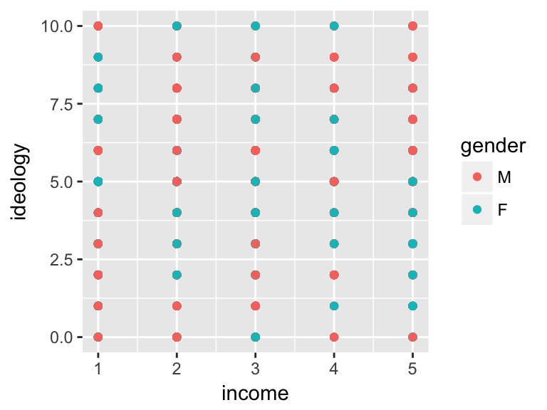

```r
plot4<-ggplot(na.omit(ces), aes(x=income, y=ideology,col=gender))+geom_point()
#Print plot4
plot4
```

#### Assignment 8

1. Instead of modifying the point colors by category of gender, change them by shape. Save it as `plot4a`

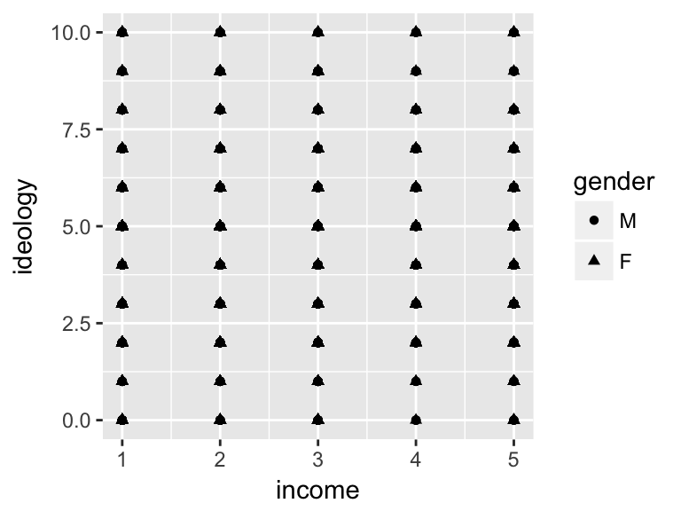

```r
plot4a<-ggplot(na.omit(ces), aes(x=income, y=ideology, shape=gender))+geom_point()
plot4a
```

### Jittering and Smoothing

You can add multiple geoms to the same plot. This is adding `layers`. It wouldn’t really make sense to add a bar plot layer to a scatterplot, but here we can `jitter` the points or we can add a `smooth` to beter show the relationships.

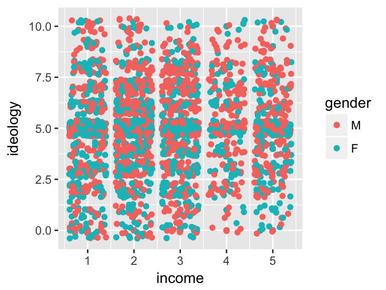

```r
plot4b<-plot4+geom_jitter(aes(col=gender))

plot4b
```

The `smooth` geom plots a linear function through points.

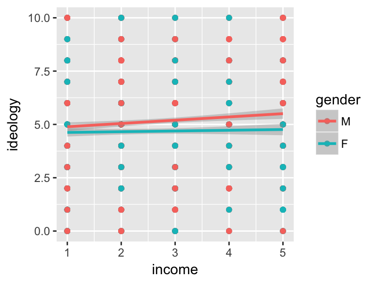

```r
plot4b<-plot4+geom_smooth(method='lm', aes(col=gender))
plot4b
```

There are two styles of faceting `facet_grid` and `facet_wrap`. Both use a formula notation which separates a left-hand side variable from a right -hand side variable with a `~`. when it comes time to fit linear models, this will be how we separate dependent from independent variables. here, we use it to separate variables that form the row panels from variables that form the column panels. and if there are no row or column variables, we can leave one side of the formula blank.

I *generally* prefer `facet_grid`

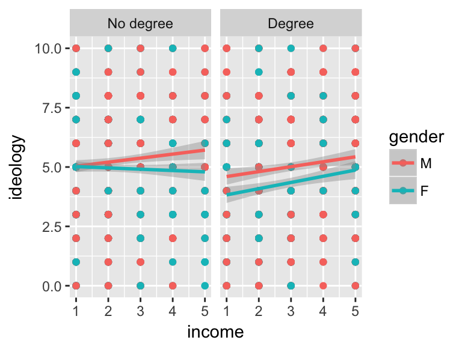

```r
plot4b+facet_grid(~degree)
```

#### Assignment 9

> 1.. Produce another scatterplot income and ideology but group the points by education using color to differentiate. Use na.omit()

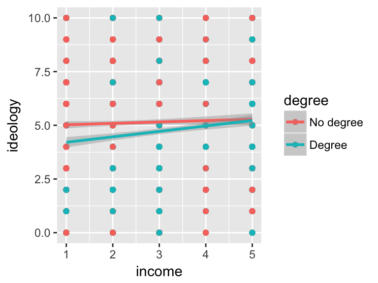

```r
plot5<-ggplot(na.omit(ces), aes(x=income, y=ideology))+geom_point(aes(col=degree))+geom_smooth(aes(col=degree), method='lm')
plot5
```

The amazing thing about R in general and what has been a major driver in it s success is that *every single part* of the plot is modifiable. Try doing that in Excel or SPSS. For example, we can change the axis labels and main title with the command `labs`().

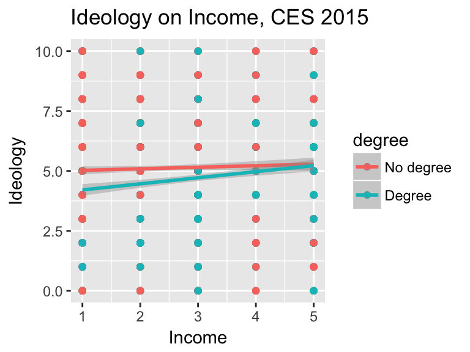

```r
plot5+labs(x='Income', y='Ideology', title='Ideology on Income, CES 2015')
```

We can also use the `cowplot()` library to combine multiple different plots.

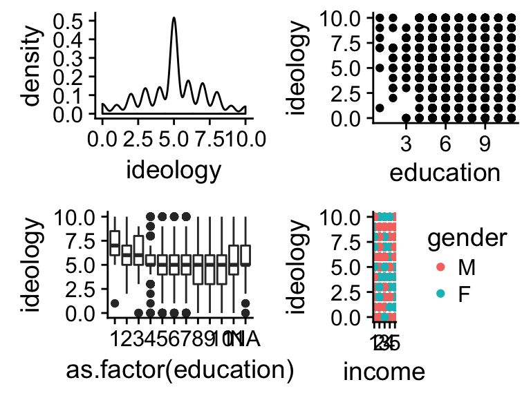

```r
library(cowplot)
plot_grid(plot1, plot2, plot3, plot4)
```

# Bivariate Analysis - Continuous

## Correlations

```r
names(ces)
str(ces)
cor(ces$ideology, ces$income, use='complete.obs')
```

# Bivariate Analysis - Categorical

## Tables

To produce contingency tables, you just use the `table` command. Here we check wither men and women differ in their views of whether inequality is a big problem.

```r
#save the table in table1
tab1<-table(ces$gender, ces$inequal)
#print table1
tab1
```

```
##
##       No  Yes
##   M  489 1275
##   F  275 1512
```

## Getting tables out of R

The easiest way to get tables out of R is to use the `xtable()` package. It is designed to take R output and prdouce either $\LaTeX$ or HTML output. We want html output becaues from there you can easily copy and paste it into a Word document.

```r
#Note load library
library(xtable)
#Print html table, note if using a PC you must change this.
print(xtable(tab1, caption='Inequality is a problem by gender'),  type='html', file='~/Desktop/tab1.html')
```

We can do a lot with this. Two common things to do with this are to produce a chi-squared test and to do a table of percentages.

```r
#Chi-sq.test
chisq.test(tab1)
```

```
##
##  Pearson's Chi-squared test with Yates' continuity correction
##
## data:  tab1
## X-squared = 79.222, df = 1, p-value < 2.2e-16
```

```r
#For prop.table you can produce either row (1) or column (2) percentgates
#Compare
prop.table(tab1, 1)
```

```
##
##            No       Yes
##   M 0.2772109 0.7227891
##   F 0.1538892 0.8461108
```

```r
#With
prop.table(tab1, 2)
```

```
##
##            No       Yes
##   M 0.6400524 0.4574812
##   F 0.3599476 0.5425188
```

# Linear Models

The linear model is very easy to fit. It uses the formula notation which involves a `~`. The dependent variable is on the left, the covariates (i.e. predictors, independent variables are on the right. )

```r
#Fit linear model
mod1<-lm(ideology ~ income, data=ces)
```

You can add a second term to the model with the `+` and interactions with a `:`.

```r
#Model 2
mod2<-lm(ideology~income+education, data=ces)
#summarize
summary(mod2)
```

```
##
## Call:
## lm(formula = ideology ~ income + education, data = ces)
##
## Residuals:
##     Min      1Q  Median      3Q     Max
## -5.6621 -1.1367 -0.0313  1.2593  5.6016
##
## Coefficients:
##             Estimate Std. Error t value Pr(>|t|)
## (Intercept)  5.42731    0.14280  38.007  < 2e-16 ***
## income       0.13135    0.02974   4.417 1.03e-05 ***
## education   -0.10548    0.01915  -5.507 3.91e-08 ***
## ---
## Signif. codes:  0 '***' 0.001 '**' 0.01 '*' 0.05 '.' 0.1 ' ' 1
##
## Residual standard error: 2.167 on 3510 degrees of freedom
##   (4059 observations deleted due to missingness)
## Multiple R-squared:  0.01113,    Adjusted R-squared:  0.01056
## F-statistic: 19.75 on 2 and 3510 DF,  p-value: 2.964e-09
```

```r
#Model 3
mod3<-lm(ideology~income+education+income:education, data=ces)
#Summarize
summary(mod3)
```

```
##
## Call:
## lm(formula = ideology ~ income + education + income:education,
##     data = ces)
##
## Residuals:
##     Min      1Q  Median      3Q     Max
## -5.4460 -1.1811 -0.0608  1.3000  5.7598
##
## Coefficients:
##                  Estimate Std. Error t value Pr(>|t|)
## (Intercept)       5.88153    0.30018  19.593  < 2e-16 ***
## income           -0.04950    0.10926  -0.453   0.6506
## education        -0.16914    0.04167  -4.059 5.03e-05 ***
## income:education  0.02443    0.01420   1.720   0.0855 .
## ---
## Signif. codes:  0 '***' 0.001 '**' 0.01 '*' 0.05 '.' 0.1 ' ' 1
##
## Residual standard error: 2.166 on 3509 degrees of freedom
##   (4059 observations deleted due to missingness)
## Multiple R-squared:  0.01196,    Adjusted R-squared:  0.01111
## F-statistic: 14.16 on 3 and 3509 DF,  p-value: 3.593e-09
```

There is a convenience function, `update()`, that allows you to modify an existing formula.

The first argument to `update()` is a model object. The second is the new model formula. You use `.` to represent the model fitting in the old model and then add whatever you wish.

```r
#New model
mod3a<-update(mod2, .~.+income:education, data=ces)
#Compare
summary(mod3)
summary(mod3a)
```

#### Assignment 11

> 1. Model support for the belief that more or less should be done to reduce income inequality with a series of linear models (ces$p_gap). Check `vals` to remind yourself what the values are. Hint: To aid in intrepretation, we might want to reverse the values of p_gap.

> Fit four different models with one variable each: income, ideology, education (as continuous) and gender. Then fit one last model with all four in one model. Then, add one more model where gender is interacted with all three of the other covariates. You should have six separate models. Summarize each.

```r
#Check
ces$p_gap
ces$gap<-Recode(ces$p_gap, "1=4; 2=3; 3=2; 4=1; 6:1000=NA")
#MODEL
m1<-lm(gap~income, data=ces)
m2<-update(m1, .~+ideology, data=ces)
m3<-update(m2, .~+education, data=ces)
m4<-update(m3, .~+gender, data=ces)
m5<-update(m1, .~.+ideology+education+gender, data=ces)
m6<-update(m5, .~.+gender:income+gender:ideology+gender:education, data=ces)
summary(m1)
summary(m2)
summary(m3)
summary(m4)
summary(m5)
summary(m6)
```

### Reporting Regressions

The `stargazer` library is by far the best package for producing well-formatted regression tables.

```r
#load library
library(stargazer)
stargazer(m1, m2, m3, m4, m5, m6, type='text')
```

[output not shown]

There are a powerful set of tools to produce diagnostic plots.  
The `broom` package is useful. The `augment()` command adds all the usual diagnostic data to the original data frame that generated the data.

```r
#load broom
library(broom)
#Augment the model m7 with the diagnostic data, store the full data frame in m7.diag
m7.diag<-augment(m7)
```

[output not shown]

Now it’s easy to plot, say the residuals against the fitted values

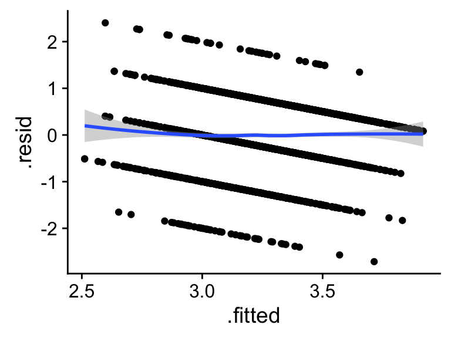

```r
ggplot(m7.diag, aes(x=.fitted, y=.resid))+geom_point()+geom_smooth(method='loess')
```

Or a `qqplot`

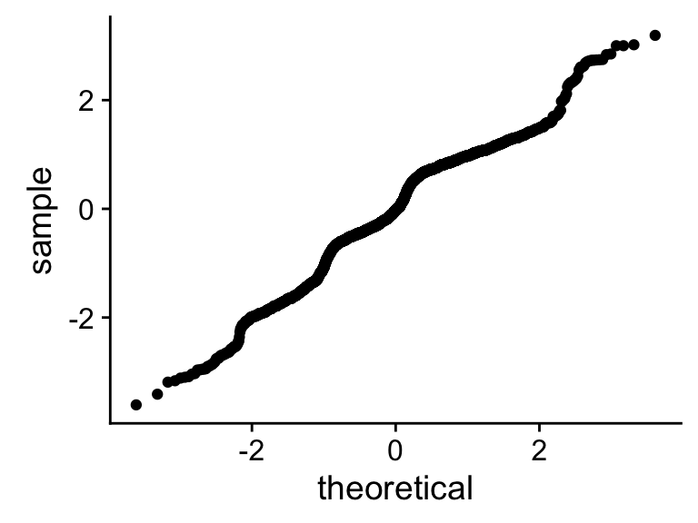

```r
ggplot(m7.diag)+geom_qq(aes(sample=m7.diag$.std.resid))
```

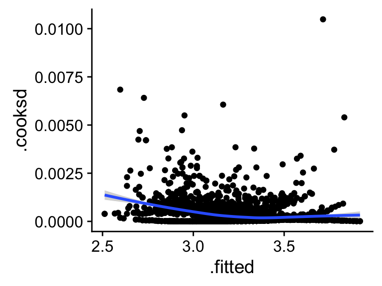

```r
ggplot(m7.diag, aes(x=.fitted, y=.cooksd))+geom_point()+geom_smooth(method='loess')
```

See [here](https://ggplot2.tidyverse.org/reference/fortify.lm.html) for a good overview on how to produce all the different plots.

## Predicted Values

There are lots of ways to generate predicted values. One of the easiest ways is the `ggeffects` package (see [here](https://cran.r-project.org/web/packages/ggeffects/vignettes/marginaleffects.html) for an introduction).

```r
library(ggeffects)
```

There are two key commands. `GGaverage` generates average predicted values, `ggpredict` generates marginal predicted values. Both take a model as its first argument and then a character vector of terms. The first element in the character vector is the term of interest, the second and third values are grouping variables.

Conveniently the output of both are ready for plotting with `ggplot2`.

```r
m7.preds<-ggpredict(m7, terms=c('ideology [0,3, 5,7,10]', 'gender'))
#summarize
m7.preds
```

```
## # A tibble: 10 x 5
##        x predicted conf.low conf.high group
##    <dbl>     <dbl>    <dbl>     <dbl> <fct>
##  1     0      3.69     3.60      3.78 M
##  2     0      3.59     3.50      3.69 F
##  3     3      3.44     3.39      3.49 M
##  4     3      3.41     3.36      3.46 F
##  5     5      3.26     3.23      3.30 M
##  6     5      3.28     3.25      3.32 F
##  7     7      3.09     3.05      3.14 M
##  8     7      3.16     3.11      3.21 F
##  9    10      2.84     2.75      2.92 M
## 10    10      2.97     2.88      3.07 F
```

```r
ggplot(m7.preds)
```

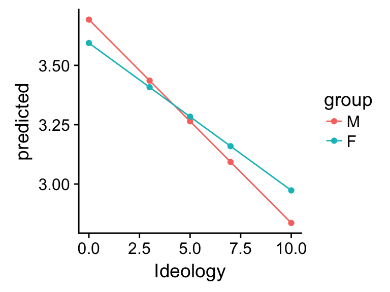

```r
ggplot(m7.preds, aes(x=x, y=predicted, col=group))+geom_point()+geom_line()+labs(x='Ideology')
```

#### Assignment 13

> 1. Generate predicted values from model m7 for ideology, gender,and income. Plot this, finding ways to group group by income and facet by gender.Save it as m7.preds2

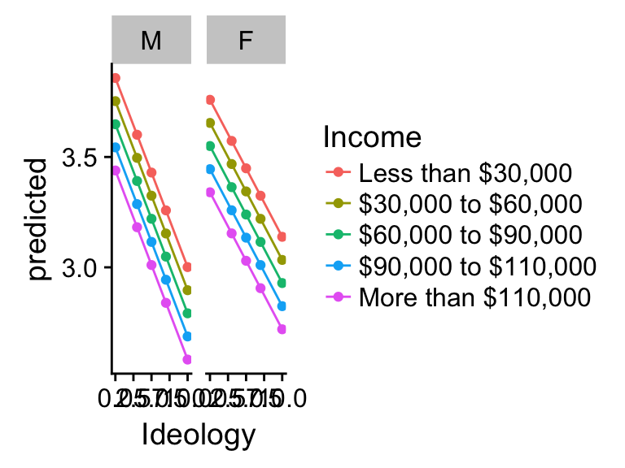

```r
m7.preds2<-ggpredict(m7, terms=c('ideology [0,3, 5,7,10]', 'income', 'gender'))
#plot
ggplot(m7.preds2, aes(x=x, y=predicted, col=group))+facet_grid(~facet)+geom_point()+geom_line()+labs(x='Ideology', col='Income')
```